# Data Manipulation

Ashkan

## Introduction

**ggplot** is a powerful and versatile data visualization package in R that has revolutionized the way data analysts and statisticians create high-quality plots. Developed by Hadley Wickham, ggplot follows the principles of the Grammar of Graphics, making it easy to construct complex visualizations by breaking them down into customizable components. With ggplot, users can effortlessly create aesthetically appealing and informative graphs by layering data, aesthetics, and geometric shapes. The package provides a wide range of customizable options for creating scatter plots, bar charts, line graphs, histograms, and more. The code-based approach of ggplot allows for a consistent and intuitive syntax, enabling users to efficiently modify and refine their visualizations. Whether for data exploration, presentation, or publication, ggplot continues to be a go-to tool for data visualization enthusiasts due to its flexibility, elegance, and seamless integration with R’s data manipulation capabilities.

## Loading packages

```r
library(gapminder)
library(car)
library(forcats)
library(tidyverse)
```

## Basics

```r
head(BOD)
```

```
##   Time demand
## 1    1    8.3
## 2    2   10.3
## 3    3   19.0
## 4    4   16.0
## 5    5   15.6
## 6    7   19.8
```

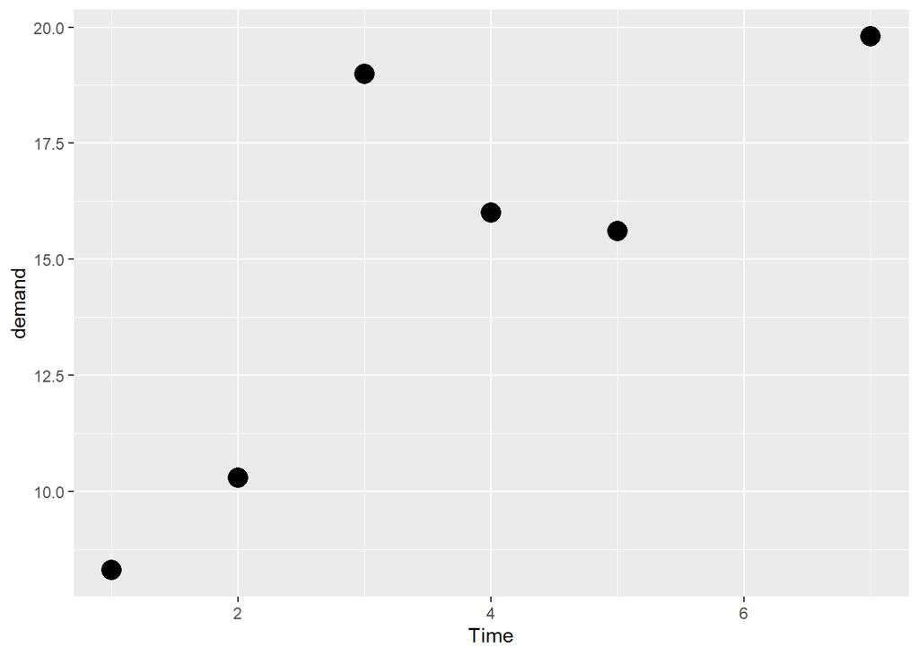

```r
ggplot(data = BOD,
       mapping = aes(x = Time,
                     y = demand))+
  geom_point(size = 5)
```

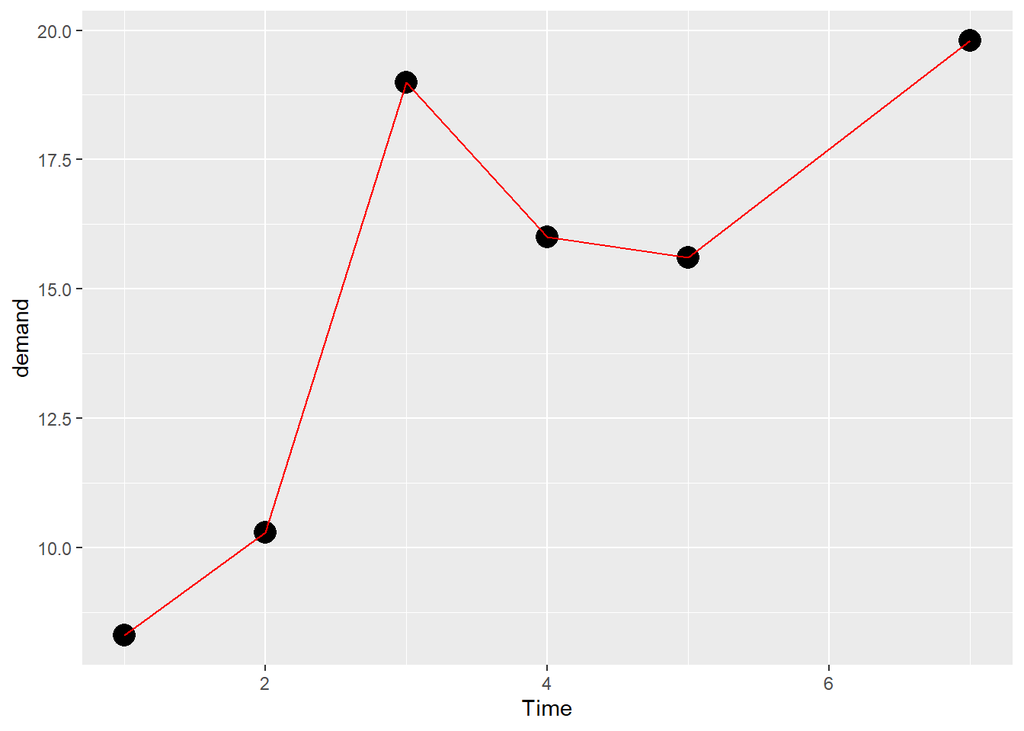

```r
ggplot(data = BOD,
       mapping = aes(x = Time,
                     y = demand))+
  geom_point(size = 5) +
  geom_line(color = "red")
```

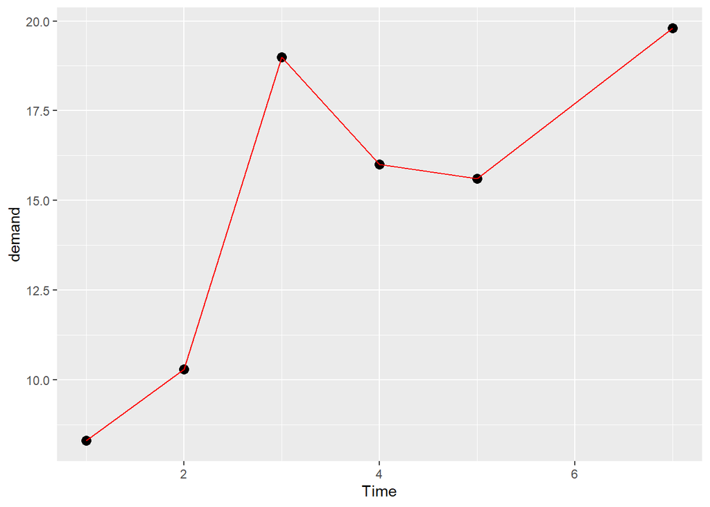

```r
ggplot(BOD, aes(Time, demand))+
  geom_point(size = 3)+
  geom_line(colour = "Red")
```

```r
head(CO2)
```

```
##   Plant   Type  Treatment conc uptake
## 1   Qn1 Quebec nonchilled   95   16.0
## 2   Qn1 Quebec nonchilled  175   30.4
## 3   Qn1 Quebec nonchilled  250   34.8
## 4   Qn1 Quebec nonchilled  350   37.2
## 5   Qn1 Quebec nonchilled  500   35.3
## 6   Qn1 Quebec nonchilled  675   39.2
```

```r
glimpse(CO2)
```

```
## Rows: 84
## Columns: 5
## $ Plant     <ord> Qn1, Qn1, Qn1, Qn1, Qn1, Qn1, Qn1, Qn2, Qn2, Qn2, Qn2, Qn2, ~
## $ Type      <fct> Quebec, Quebec, Quebec, Quebec, Quebec, Quebec, Quebec, Queb~
## $ Treatment <fct> nonchilled, nonchilled, nonchilled, nonchilled, nonchilled, ~
## $ conc      <dbl> 95, 175, 250, 350, 500, 675, 1000, 95, 175, 250, 350, 500, 6~
## $ uptake    <dbl> 16.0, 30.4, 34.8, 37.2, 35.3, 39.2, 39.7, 13.6, 27.3, 37.1, ~
```

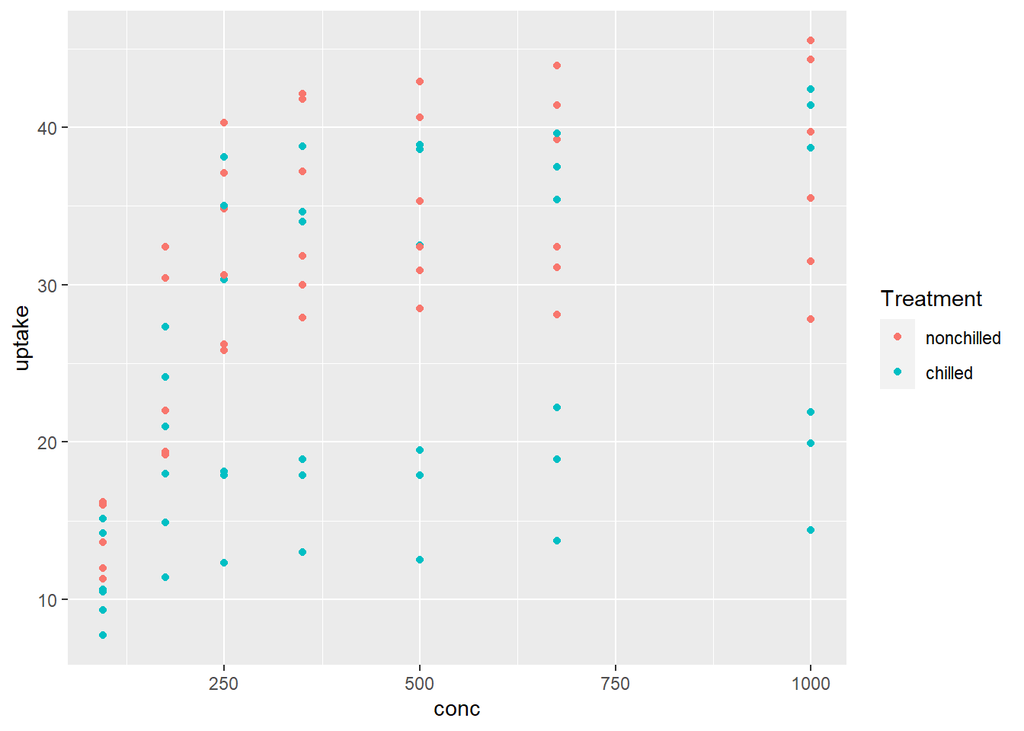

```r
CO2 %>%
  # x = and y = can be deleted
  ggplot(aes(x = conc, y =  uptake,
             color = Treatment))+
  geom_point()
```

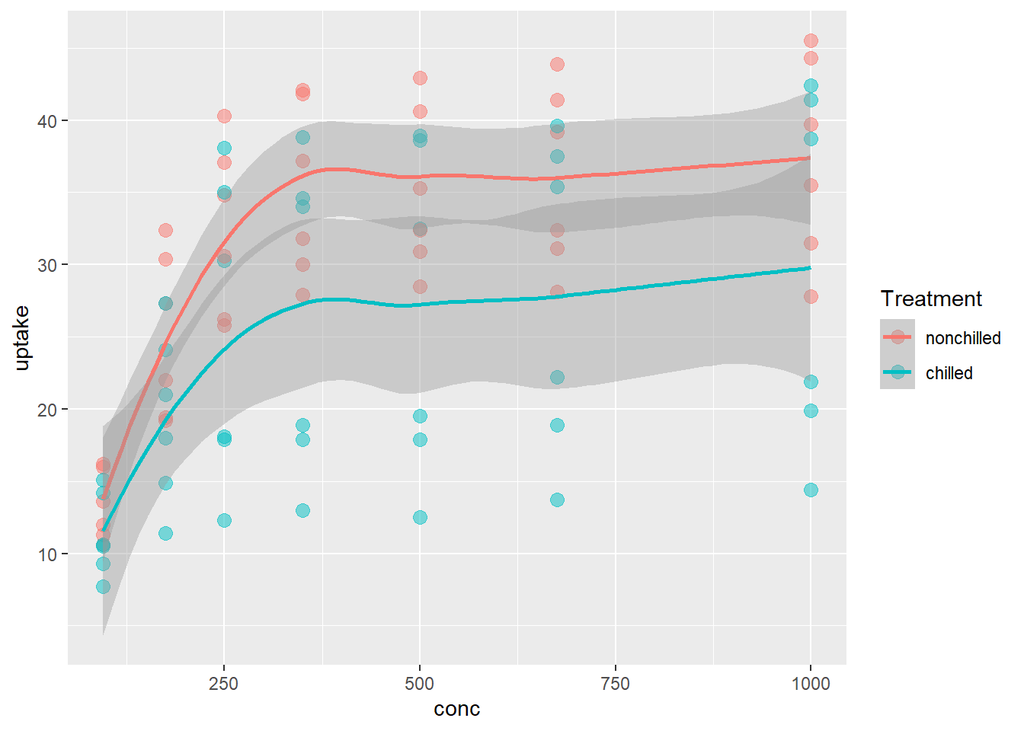

```r
CO2 %>%
  ggplot(aes(x = conc, y =  uptake,
             color = Treatment))+
  geom_point(size = 3, alpha = 0.5)+
  geom_smooth()
```

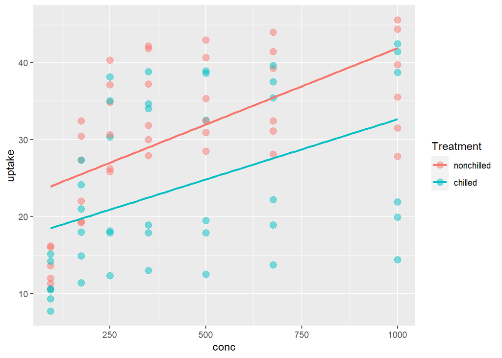

```r
CO2 %>%
  ggplot(aes(x = conc, y =  uptake,
             color = Treatment))+
  geom_point(size = 3, alpha = 0.5)+
  geom_smooth(method = lm, se = F)
```

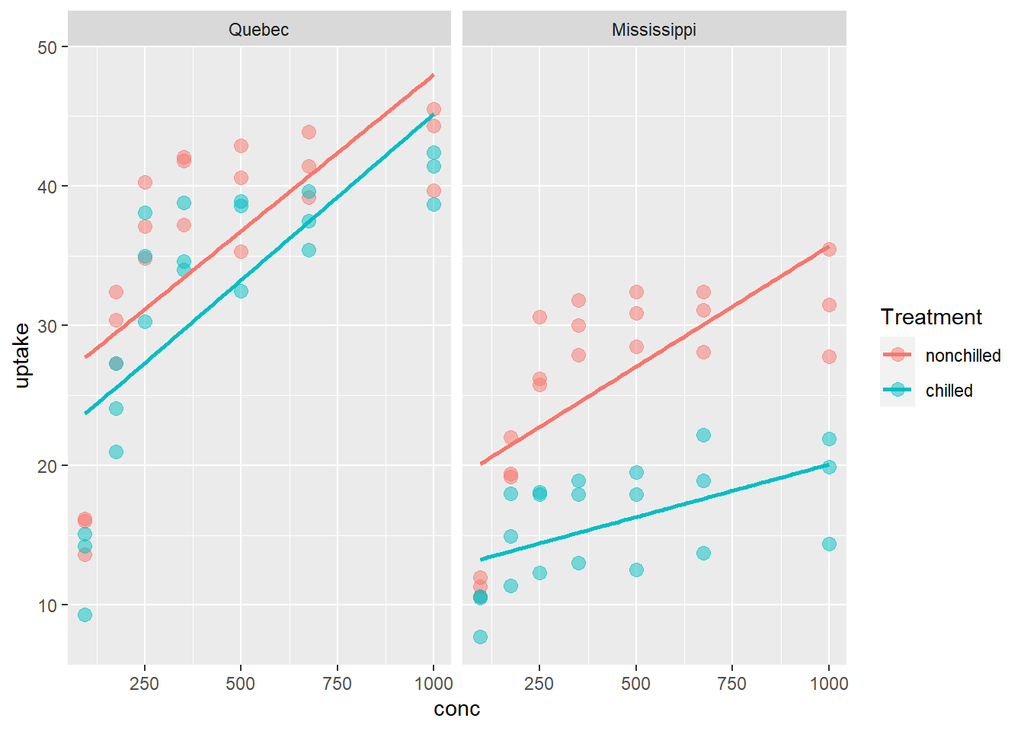

```r
CO2 %>%
  ggplot(aes(x = conc, y =  uptake,
             color = Treatment))+
  geom_point(size = 3, alpha = 0.5)+
  geom_smooth(method = lm, se = F)+
  facet_wrap(~Type)
```

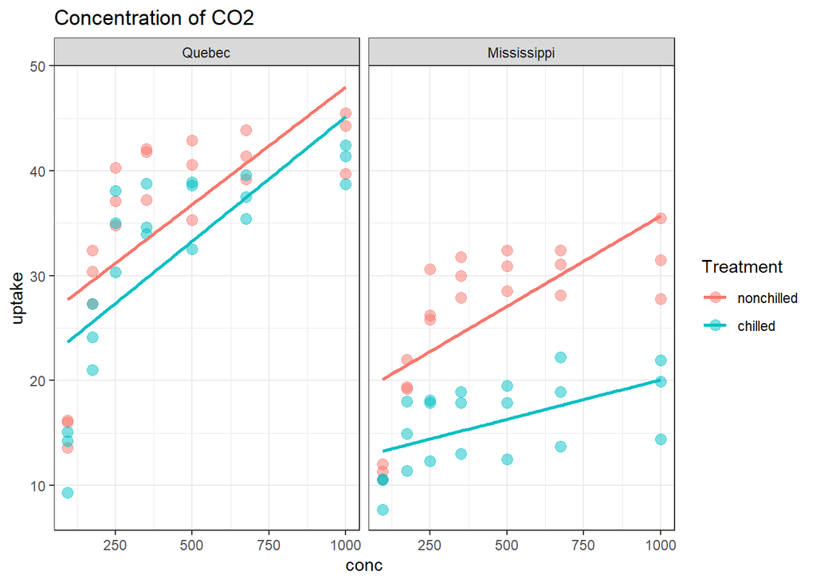

```r
CO2 %>%
  ggplot(aes(x = conc, y =  uptake,
             color = Treatment))+
  geom_point(size = 3, alpha = 0.5)+
  geom_smooth(method = lm, se = F)+
  facet_wrap(~Type)+
  labs(title = "Concentration of CO2")+
  theme_bw()
```

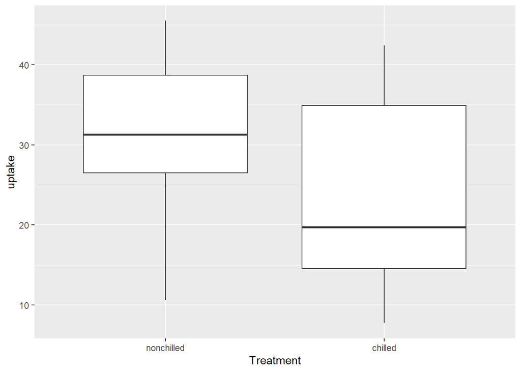

```r
CO2 %>%
  ggplot(aes(Treatment, uptake))+
  geom_boxplot()
```

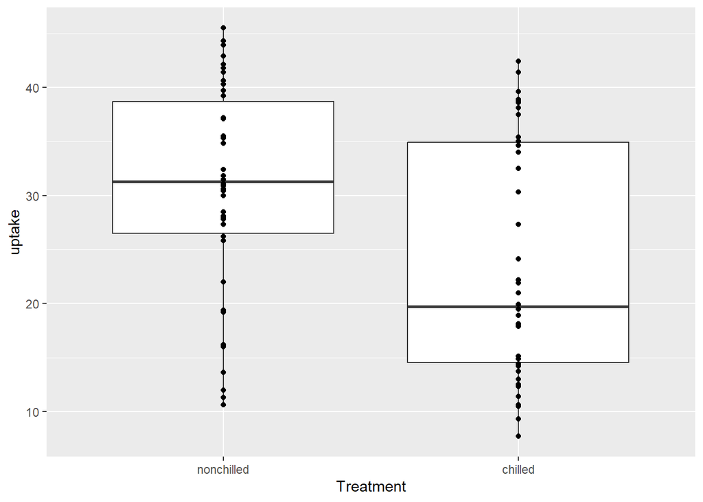

```r
CO2 %>%
  ggplot(aes(Treatment, uptake))+
  geom_boxplot()+
  geom_point()
```

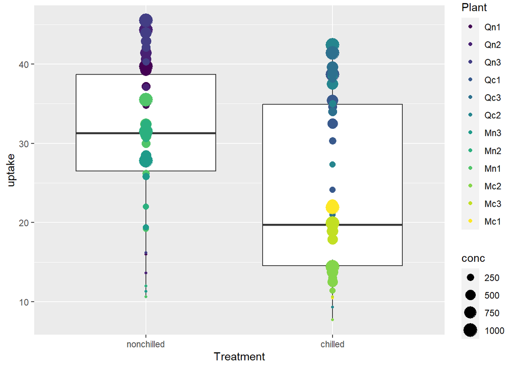

```r
# Add mapping just for the point
# mapping can be done in original ggplot or
# in geometry with different reult
CO2 %>%
  ggplot(aes(Treatment, uptake))+
  geom_boxplot()+
  geom_point(aes(size = conc,
                 colour = Plant))
```

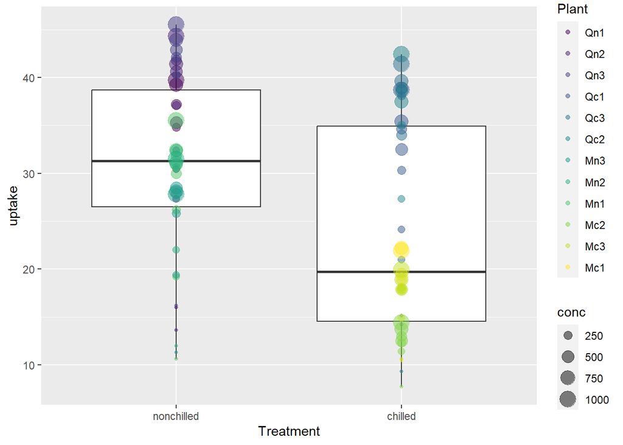

```r
CO2 %>%
  ggplot(aes(Treatment, uptake))+
  geom_boxplot()+
  geom_point(alpha = 0.5
             ,aes(size = conc,
                 colour = Plant))
```

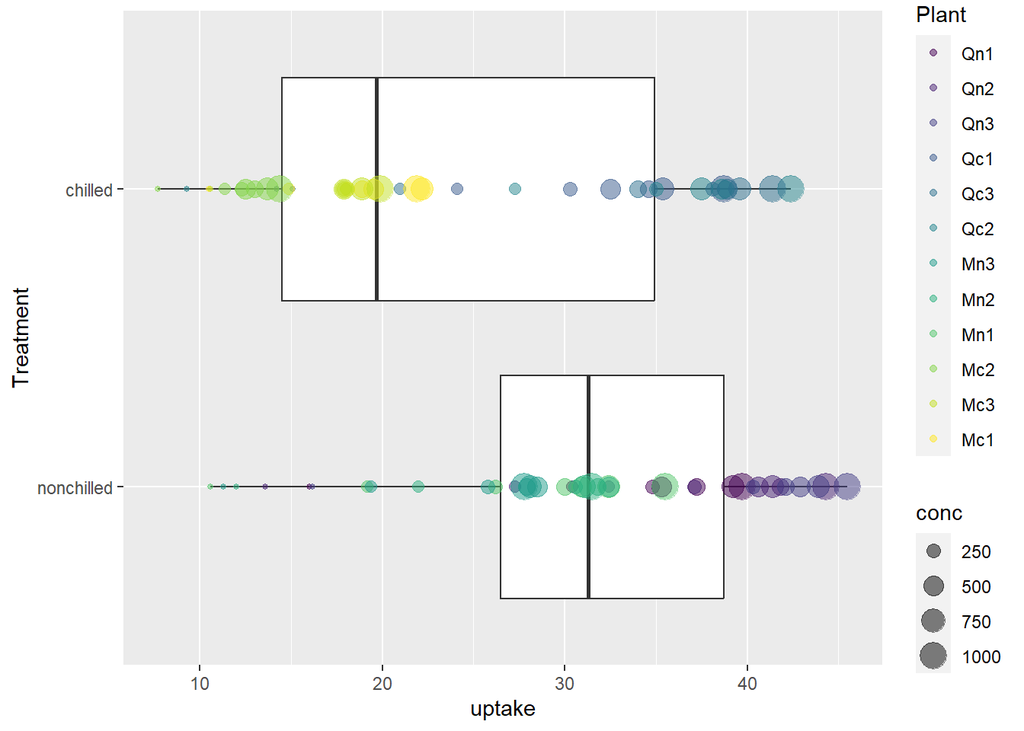

```r
CO2 %>%
  ggplot(aes(Treatment, uptake))+
  geom_boxplot()+
  geom_point(alpha = 0.5
             ,aes(size = conc,
                 colour = Plant))+
  coord_flip()
```

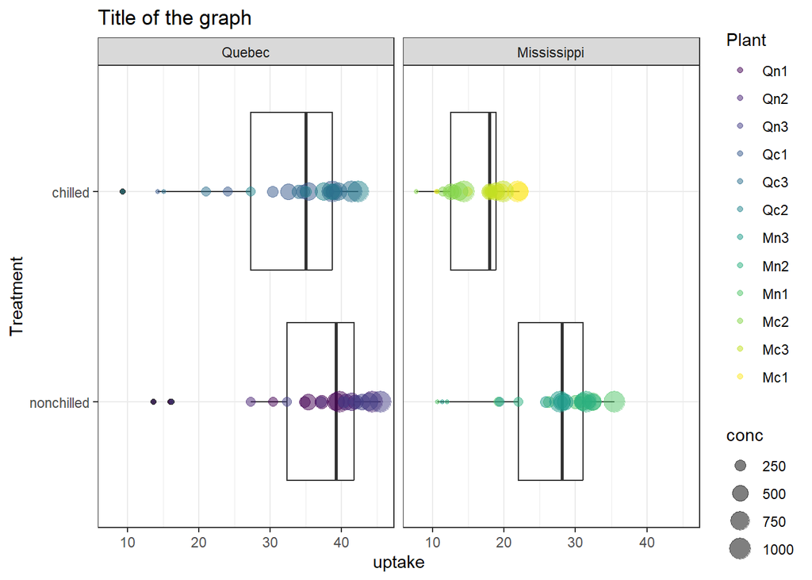

```r
CO2 %>%
  ggplot(aes(Treatment, uptake))+
  geom_boxplot()+
  geom_point(alpha = 0.5
             ,aes(size = conc,
                 colour = Plant))+
  coord_flip()+
  facet_wrap(~Type)+
  labs(title = "Title of the graph")+
  theme_bw()
```

```r
head(mpg)
```

```
## # A tibble: 6 x 11
##   manufacturer model displ  year   cyl trans      drv     cty   hwy fl    class
##   <chr>        <chr> <dbl> <int> <int> <chr>      <chr> <int> <int> <chr> <chr>
## 1 audi         a4      1.8  1999     4 auto(l5)   f        18    29 p     compa~
## 2 audi         a4      1.8  1999     4 manual(m5) f        21    29 p     compa~
## 3 audi         a4      2    2008     4 manual(m6) f        20    31 p     compa~
## 4 audi         a4      2    2008     4 auto(av)   f        21    30 p     compa~
## 5 audi         a4      2.8  1999     6 auto(l5)   f        16    26 p     compa~
## 6 audi         a4      2.8  1999     6 manual(m5) f        18    26 p     compa~
```

```r
glimpse(mpg)
```

```
## Rows: 234
## Columns: 11
## $ manufacturer <chr> "audi", "audi", "audi", "audi", "audi", "audi", "audi", "~
## $ model        <chr> "a4", "a4", "a4", "a4", "a4", "a4", "a4", "a4 quattro", "~
## $ displ        <dbl> 1.8, 1.8, 2.0, 2.0, 2.8, 2.8, 3.1, 1.8, 1.8, 2.0, 2.0, 2.~
## $ year         <int> 1999, 1999, 2008, 2008, 1999, 1999, 2008, 1999, 1999, 200~
## $ cyl          <int> 4, 4, 4, 4, 6, 6, 6, 4, 4, 4, 4, 6, 6, 6, 6, 6, 6, 8, 8, ~
## $ trans        <chr> "auto(l5)", "manual(m5)", "manual(m6)", "auto(av)", "auto~
## $ drv          <chr> "f", "f", "f", "f", "f", "f", "f", "4", "4", "4", "4", "4~
## $ cty          <int> 18, 21, 20, 21, 16, 18, 18, 18, 16, 20, 19, 15, 17, 17, 1~
## $ hwy          <int> 29, 29, 31, 30, 26, 26, 27, 26, 25, 28, 27, 25, 25, 25, 2~
## $ fl           <chr> "p", "p", "p", "p", "p", "p", "p", "p", "p", "p", "p", "p~
## $ class        <chr> "compact", "compact", "compact", "compact", "compact", "c~
```

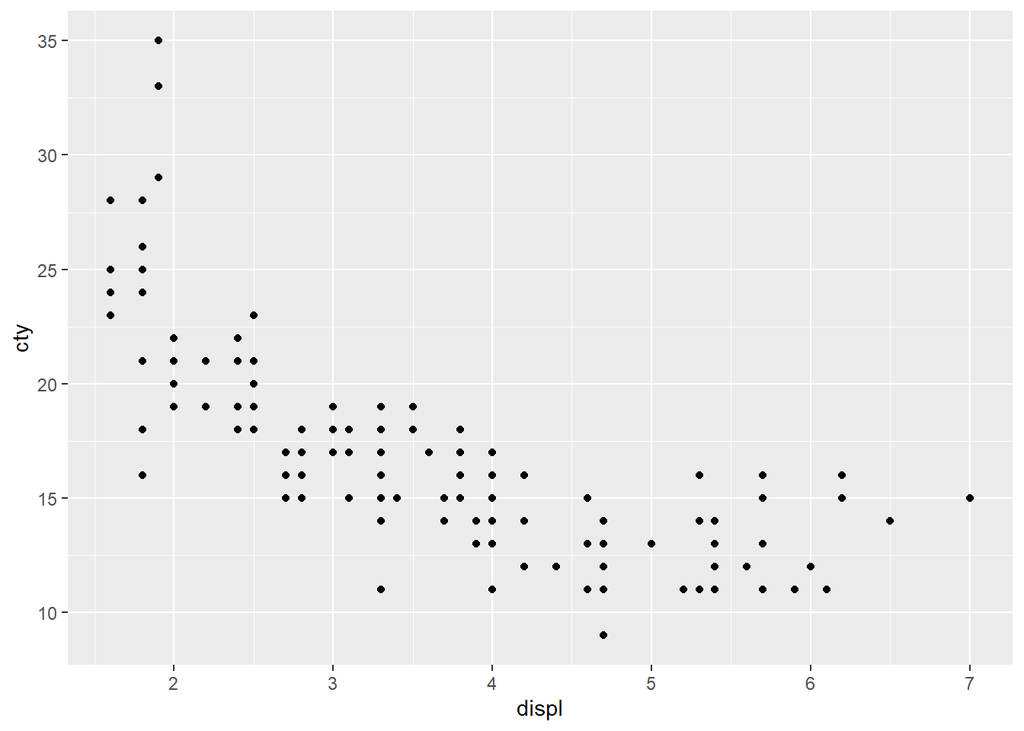

```r
mpg %>%
  ggplot(aes(displ, cty))+
  geom_point()
```

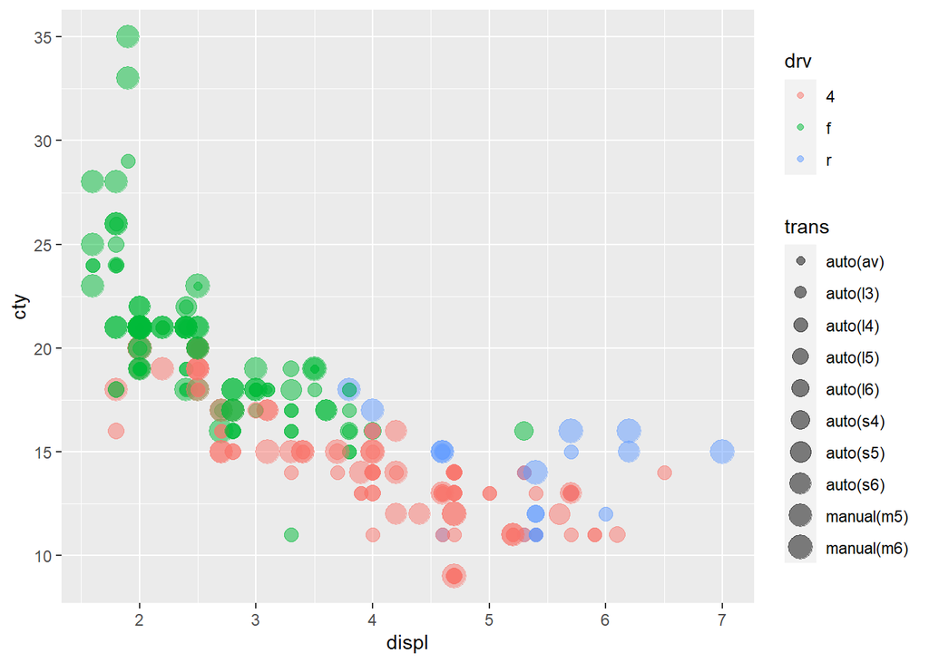

```r
mpg %>%
  ggplot(aes(displ, cty))+
  geom_point(aes(colour = drv,
                 size = trans),
             alpha = 0.5)
```

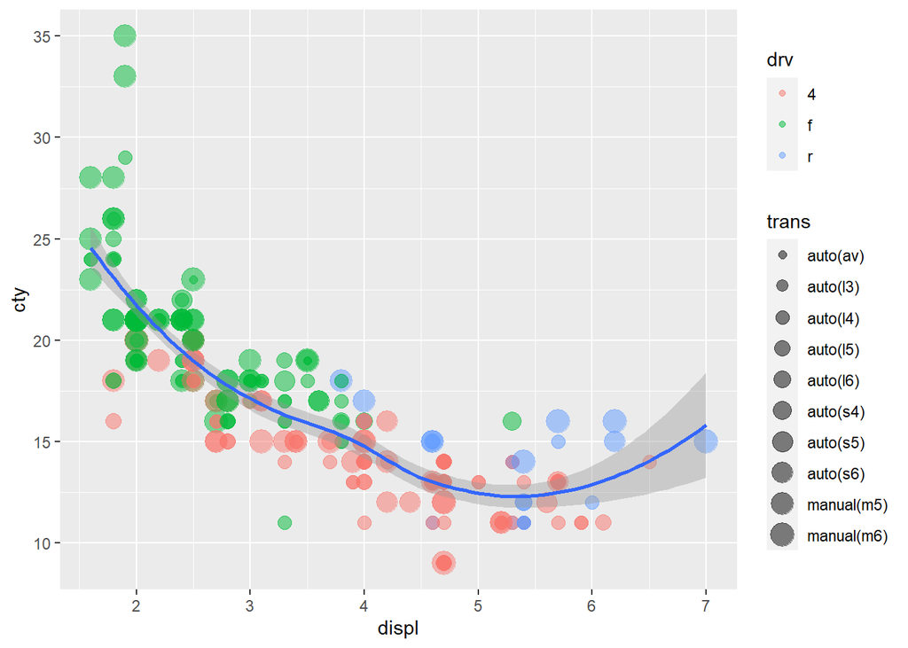

```r
mpg %>%
  ggplot(aes(displ, cty))+
  geom_point(aes(colour = drv,
                 size = trans),
             alpha = 0.5)+
  geom_smooth()
```

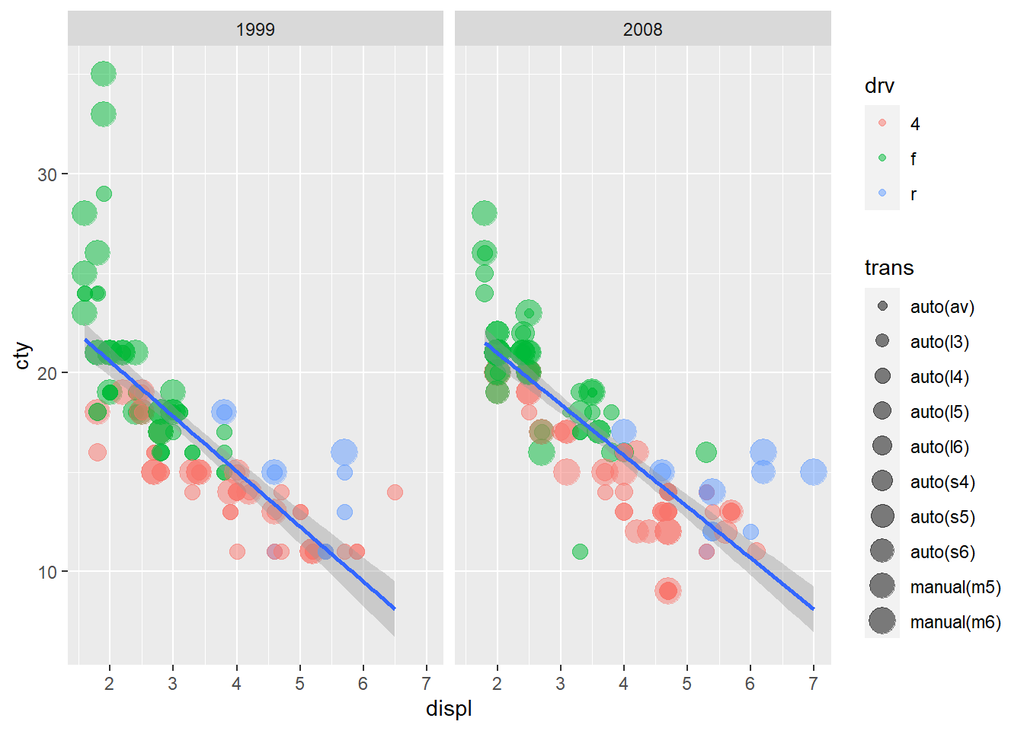

```r
mpg %>%
  ggplot(aes(displ, cty))+
  geom_point(aes(colour = drv,
                 size = trans),
             alpha = 0.5)+
  geom_smooth(method = lm)+
  facet_wrap(~year, nrow = 1)
```

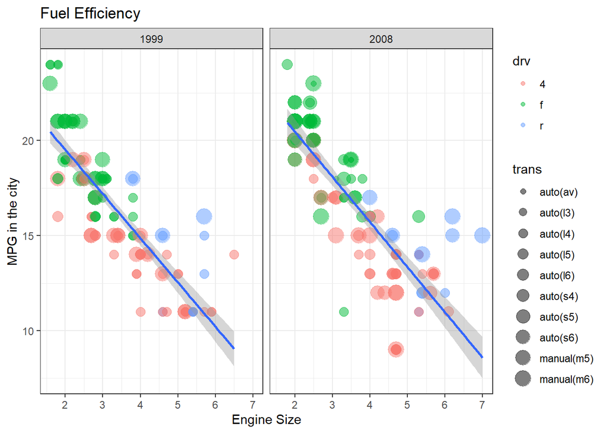

```r
mpg %>%
  filter(cty < 25) %>%
  ggplot(aes(displ, cty))+
  geom_point(aes(colour = drv,
                 size = trans),
             alpha = 0.5)+
  geom_smooth(method = lm)+
  facet_wrap(~year, nrow = 1)+
  labs(x = "Engine Size",
       y = "MPG in the city",
       title = "Fuel Efficiency")+
  theme_bw()
```

## Scatter plots

Two numerical variables

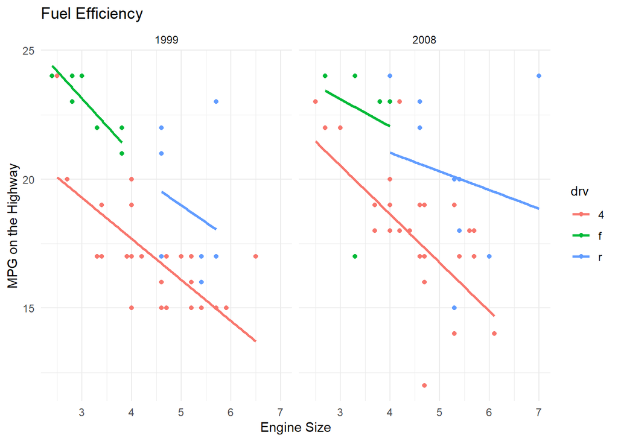

```r
mpg %>%
  filter(hwy < 25) %>%
  ggplot(aes(x = displ,
             y = hwy,
             colour = drv))+
  geom_point()+
  geom_smooth(method = lm,
              se = F)+
  facet_wrap(~year, nrow = 1)+
  labs(x = "Engine Size",
       y = "MPG on the Highway",
       title = "Fuel Efficiency")+
  theme_minimal()
```

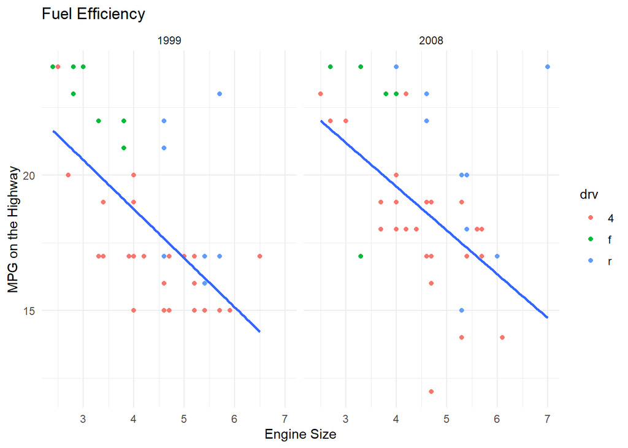

```r
mpg %>%
  filter(hwy < 25) %>%
  ggplot(aes(x = displ,
             y = hwy))+
  geom_point(aes(colour = drv))+
  geom_smooth(method = lm,
              se = F)+
  facet_wrap(~year, nrow = 1)+
  labs(x = "Engine Size",
       y = "MPG on the Highway",
       title = "Fuel Efficiency")+
  theme_minimal()
```

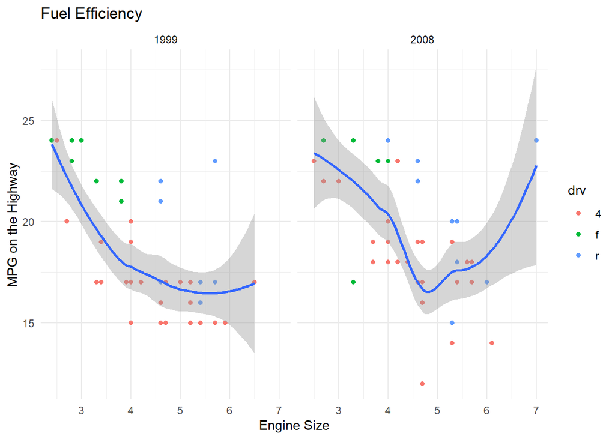

```r
mpg %>%
  filter(hwy < 25) %>%
  ggplot(aes(x = displ,
             y = hwy))+
  geom_point(aes(colour = drv))+
  geom_smooth()+
  facet_wrap(~year, nrow = 1)+
  labs(x = "Engine Size",
       y = "MPG on the Highway",
       title = "Fuel Efficiency")+
  theme_minimal()
```

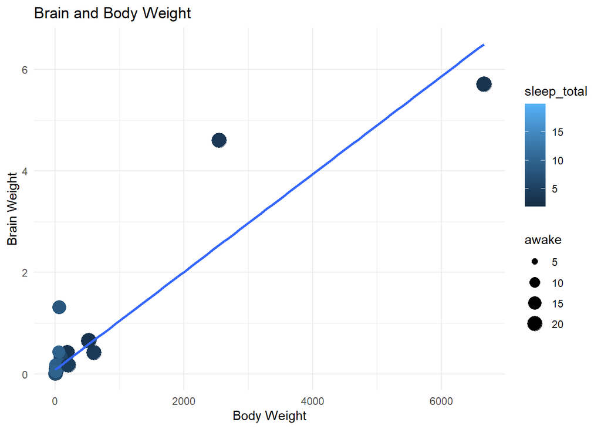

```r
# for multiple numeric variable scater plot is used
msleep %>%
  ggplot(mapping = aes(x = bodywt, y = brainwt))+
  geom_point(aes(colour = sleep_total,
                 size = awake))+
  geom_smooth(method = lm, se = F)+
  labs(x = "Body Weight",
       y = "Brain Weight",
       title = "Brain and Body Weight")+
  theme_minimal()
```

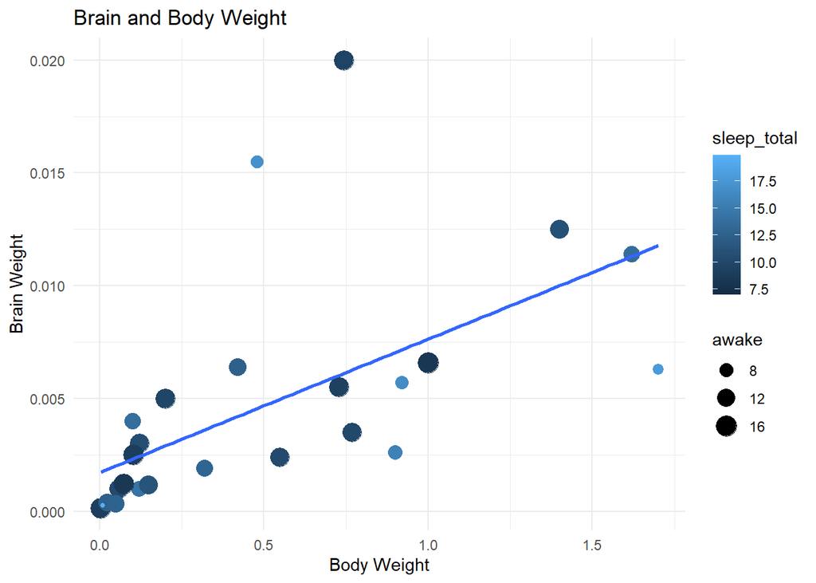

```r
msleep %>%
  filter(bodywt < 2) %>%
  ggplot(mapping = aes(x = bodywt, y = brainwt))+
  geom_point(aes(colour = sleep_total,
                 size = awake))+
  geom_smooth(method = lm, se = F)+
  labs(x = "Body Weight",
       y = "Brain Weight",
       title = "Brain and Body Weight")+
  theme_minimal()
```

## Bar charts and Histograms

One numerical variable (density, box plot, violin plots can be used)

```r
head(msleep)
```

```
## # A tibble: 6 x 11
##   name    genus vore  order conservation sleep_total sleep_rem sleep_cycle awake
##   <chr>   <chr> <chr> <chr> <chr>              <dbl>     <dbl>       <dbl> <dbl>
## 1 Cheetah Acin~ carni Carn~ lc                  12.1      NA        NA      11.9
## 2 Owl mo~ Aotus omni  Prim~ <NA>                17         1.8      NA       7
## 3 Mounta~ Aplo~ herbi Rode~ nt                  14.4       2.4      NA       9.6
## 4 Greate~ Blar~ omni  Sori~ lc                  14.9       2.3       0.133   9.1
## 5 Cow     Bos   herbi Arti~ domesticated         4         0.7       0.667  20
## 6 Three-~ Brad~ herbi Pilo~ <NA>                14.4       2.2       0.767   9.6
## # i 2 more variables: brainwt <dbl>, bodywt <dbl>
```

```r
glimpse(msleep)
```

```
## Rows: 83
## Columns: 11
## $ name         <chr> "Cheetah", "Owl monkey", "Mountain beaver", "Greater shor~
## $ genus        <chr> "Acinonyx", "Aotus", "Aplodontia", "Blarina", "Bos", "Bra~
## $ vore         <chr> "carni", "omni", "herbi", "omni", "herbi", "herbi", "carn~
## $ order        <chr> "Carnivora", "Primates", "Rodentia", "Soricomorpha", "Art~
## $ conservation <chr> "lc", NA, "nt", "lc", "domesticated", NA, "vu", NA, "dome~
## $ sleep_total  <dbl> 12.1, 17.0, 14.4, 14.9, 4.0, 14.4, 8.7, 7.0, 10.1, 3.0, 5~
## $ sleep_rem    <dbl> NA, 1.8, 2.4, 2.3, 0.7, 2.2, 1.4, NA, 2.9, NA, 0.6, 0.8, ~
## $ sleep_cycle  <dbl> NA, NA, NA, 0.1333333, 0.6666667, 0.7666667, 0.3833333, N~
## $ awake        <dbl> 11.9, 7.0, 9.6, 9.1, 20.0, 9.6, 15.3, 17.0, 13.9, 21.0, 1~
## $ brainwt      <dbl> NA, 0.01550, NA, 0.00029, 0.42300, NA, NA, NA, 0.07000, 0~
## $ bodywt       <dbl> 50.000, 0.480, 1.350, 0.019, 600.000, 3.850, 20.490, 0.04~
```

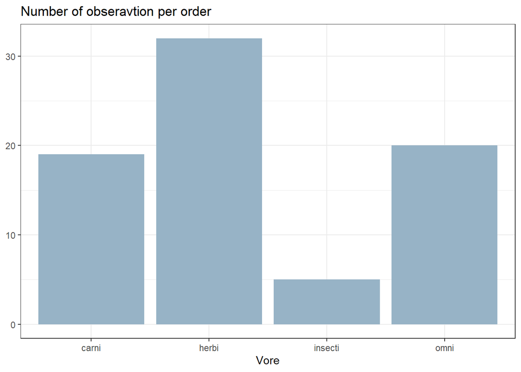

```r
# for categorical variable bar chart
msleep %>%
  drop_na(vore) %>%
  ggplot(aes(x = vore))+
  geom_bar(fill = "#97B3C6")+
  theme_bw()+
  labs(x = "Vore",
       y = NULL,
       title = "Number of obseravtion per order")
```

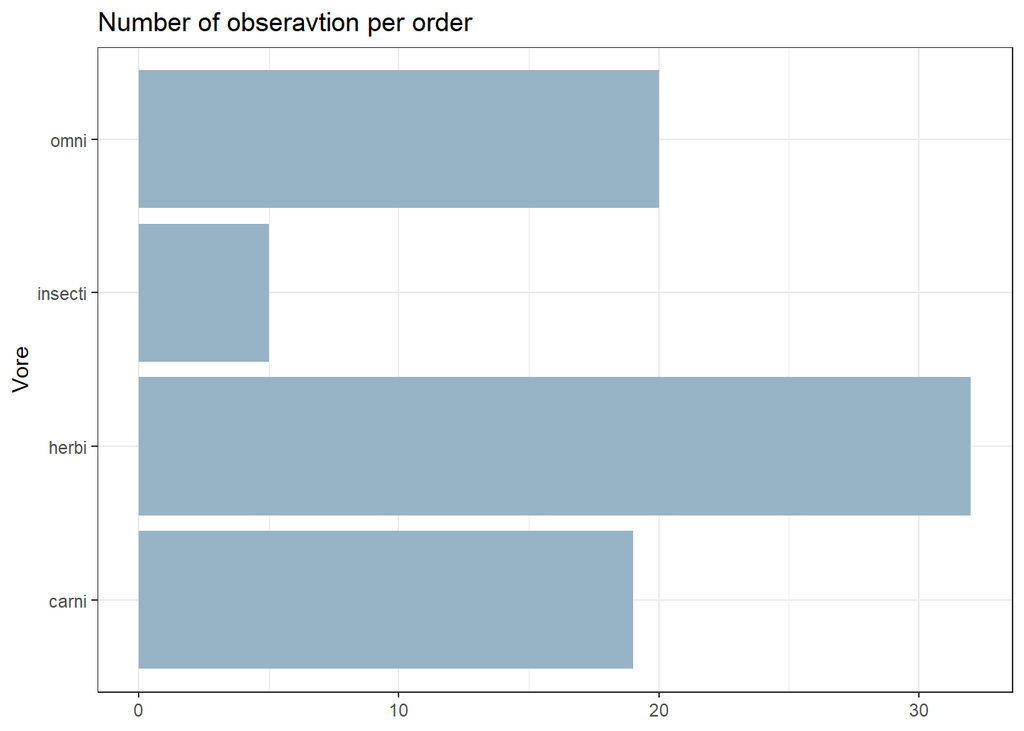

```r
msleep %>%
  drop_na(vore) %>%
  ggplot(aes(x = vore))+
  geom_bar(fill = "#97B3C6")+
  coord_flip()+
  theme_bw()+
  labs(x = "Vore",
       y = NULL,
       title = "Number of obseravtion per order")
```

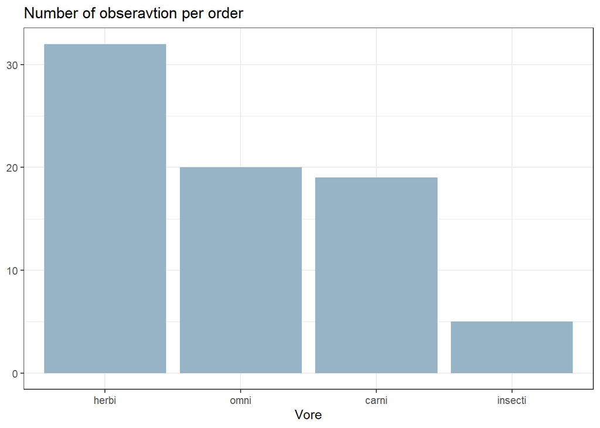

```r
msleep %>%
  drop_na(vore) %>%
  ggplot(aes(x = fct_infreq(vore)))+
  geom_bar(fill = "#97B3C6")+
  theme_bw()+
  labs(x = "Vore",
       y = NULL,
       title = "Number of obseravtion per order")
```

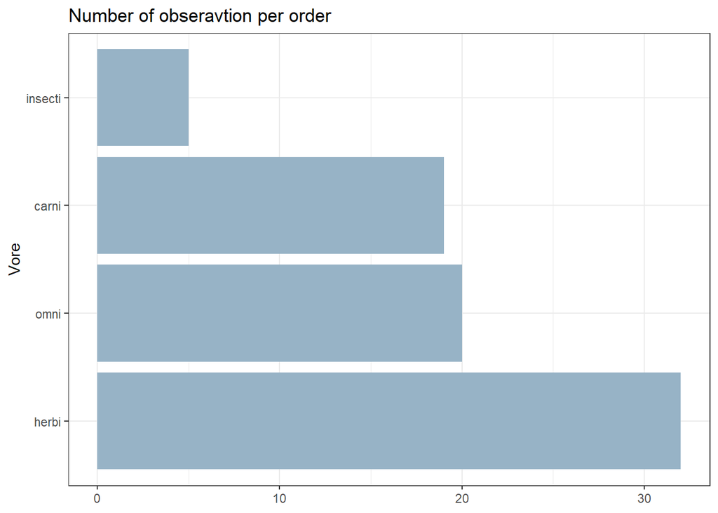

```r
msleep %>%
  drop_na(vore) %>%
  ggplot(aes(x = fct_infreq(vore)))+
  geom_bar(fill = "#97B3C6")+
  coord_flip()+
  theme_bw()+
  labs(x = "Vore",
       y = NULL,
       title = "Number of obseravtion per order")
```

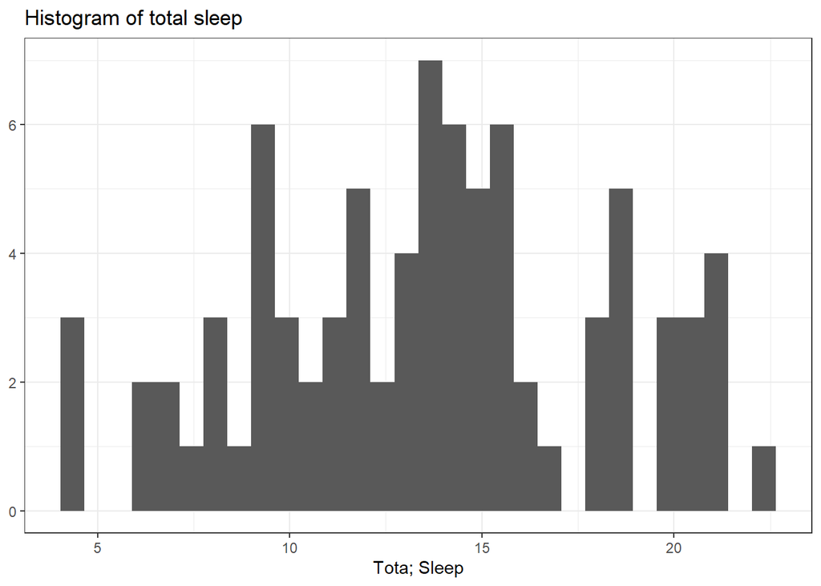

```r
# for numerical variable histogram
msleep %>%
  ggplot(aes(x = awake))+
  geom_histogram()+
  theme_bw()+
  labs(x = "Tota; Sleep",
       y = NULL,
       title = "Histogram of total sleep")
```

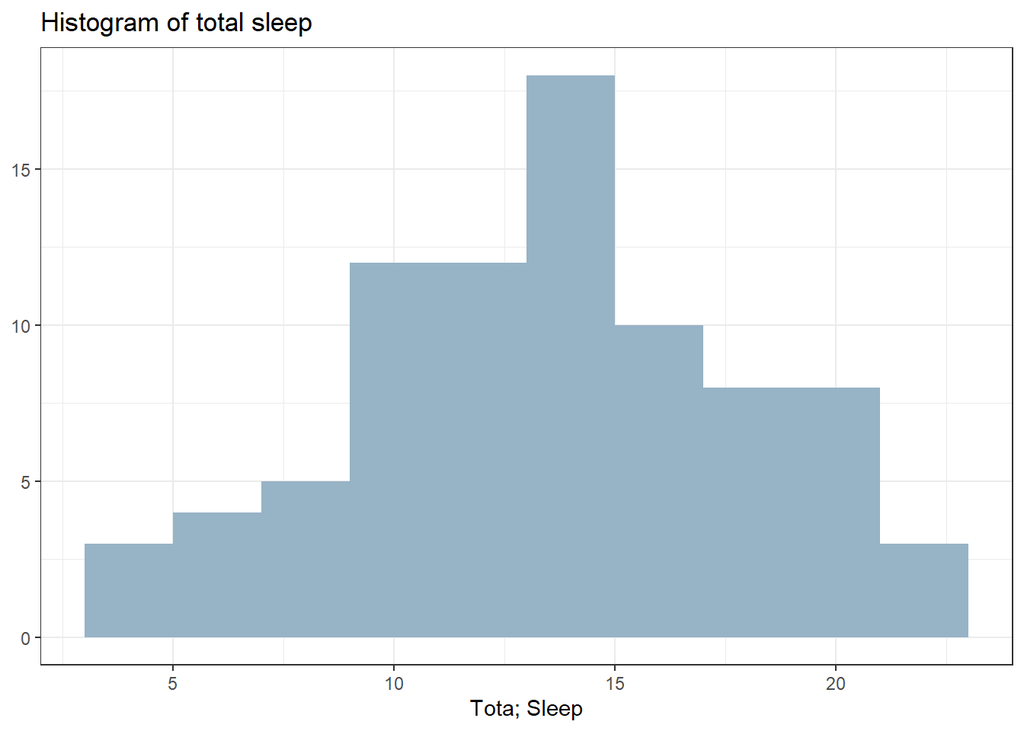

```r
msleep %>%
  ggplot(aes(x = awake))+
  geom_histogram(binwidth = 2, fill = "#97B3C6")+
  theme_bw()+
  labs(x = "Tota; Sleep",
       y = NULL,
       title = "Histogram of total sleep")
```

## line graph

For two numeric and one categorical variables

```r
head(Orange)
```

```
## Grouped Data: circumference ~ age | Tree
##   Tree  age circumference
## 1    1  118            30
## 2    1  484            58
## 3    1  664            87
## 4    1 1004           115
## 5    1 1231           120
## 6    1 1372           142
```

```r
glimpse(Orange)
```

```
## Rows: 35
## Columns: 3
## $ Tree          <ord> 1, 1, 1, 1, 1, 1, 1, 2, 2, 2, 2, 2, 2, 2, 3, 3, 3, 3, 3,~
## $ age           <dbl> 118, 484, 664, 1004, 1231, 1372, 1582, 118, 484, 664, 10~
## $ circumference <dbl> 30, 58, 87, 115, 120, 142, 145, 33, 69, 111, 156, 172, 2~
```

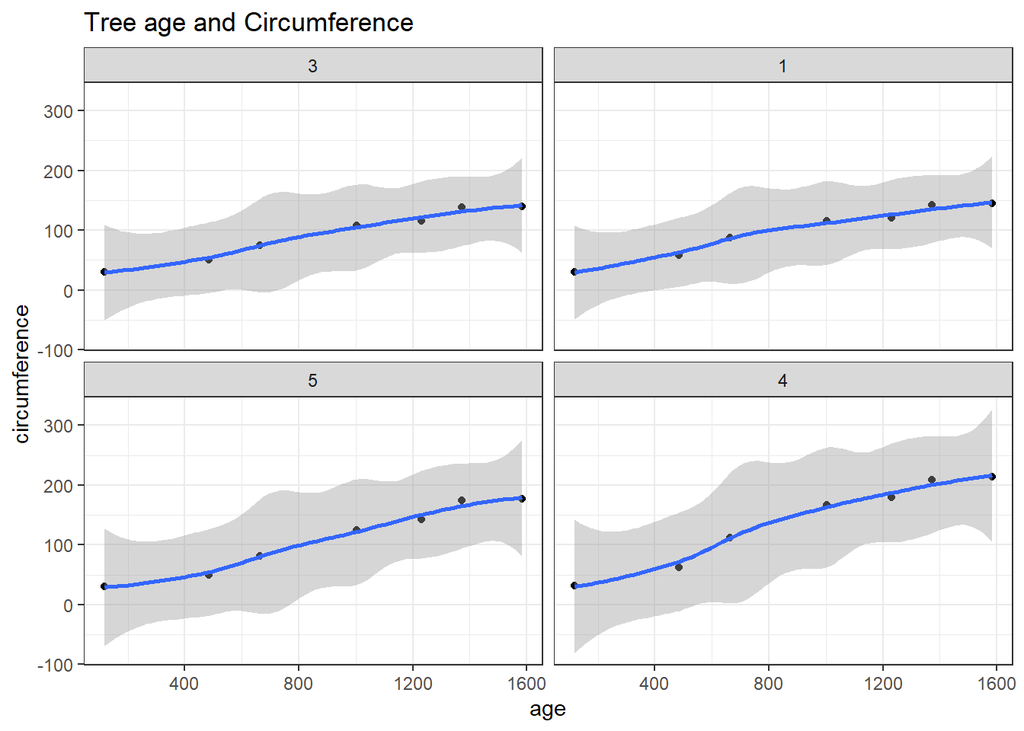

```r
Orange %>%
  filter(Tree != "2") %>%
  ggplot(aes(age, circumference))+
  geom_point()+
  geom_smooth()+
  facet_wrap(~Tree)+
  theme_bw()+
  labs(title = "Tree age and Circumference")
```

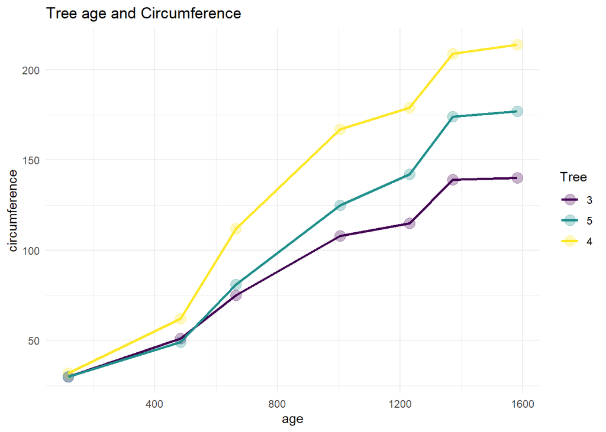

```r
Orange %>%
  filter(Tree != "2" &
           Tree != "1") %>%
  ggplot(aes(age, circumference, colour = Tree))+
  geom_point(size = 4, alpha = 0.3)+
  geom_line(linewidth = 1)+
  theme_minimal()+
  labs(title = "Tree age and Circumference")
```